# Proyecto de Ciencia de Datos

2024-08-08

## Tabla resumen

A continuación se presenta una tabla con un resumen aleatorio de los contenidos presentes y utilizados en los datos que se han utilizado a lo largo del proyecto:

Muestra aleatoria de datos

| ID | País | Total TV (frec) | TV Política (frec) | Confianza | Justicia | Ayuda |
| --- | --- | --- | --- | --- | --- | --- |
| 94 | BG | 7 | 2 | 0 | 0 | 2 |
| 2388 | IL | 5 | 5 | 3 | 5 | 5 |
| 2097 | IL | 3 | 1 | 2 | 0 | 3 |
| 1136 | PL | 6 | 4 | 3 | 3 | 2 |
| 110408 | BE | 2 | 7 | 3 | 3 | 3 |

## Gráfico principales resultados

Este gráfico muestra la primera relación que se ha analizado. En este caso, el tiempo que se consumen noticias en la televisión y la confianza que se tiene en la gente.

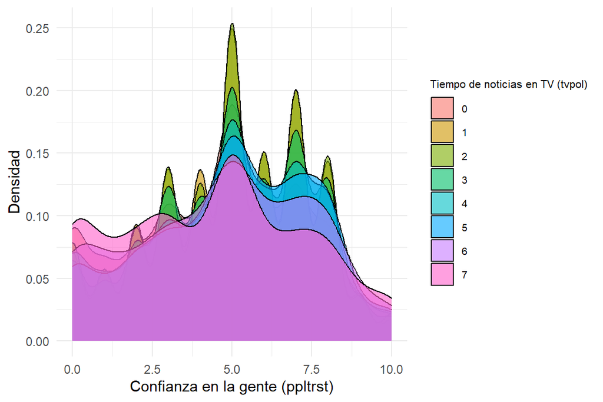

## Acerca del estudio

En este estudio, se han analizado las relaciones entre el tiempo que se consume la televisión, más en concreto contenido político o de notícias, con medidas de confianza en la gente, en su sentido de la justícia y su capacidad de ayudar a otras personas.

Para entender mejor la relación entre el tiempo dedicado a ver televisión política (`tvpol`) y la confianza en la buena fe de la gente (`Confianza`), se ha calculado el coeficiente de correlación de Pearson.

Como resultado obtenemos **-0.0032411**, esto nos indica una correlación muy débil entre las dos variables, lo que nos dice que hay muy poca o ninguna relación lineal entre el tiempo que se miran noticias en la televisión y la confianza que se tiene en la gente.